# MidtermProject_Predicting the houseprice of San Francisco

Xintian Li & Jingzhi Chang

October 15, 2019

# 1.Introduction

This project aims to predict house prices in San Francisco. In this project, we build an Ordinary Least Square model and simulate the linear relationship between house prices and related preditor variables. While training the model, we care about both accuracy and generalizability and try to make a balance between these two standards. In other words, we hope the model trained with known house prices could predict the prices of the houses never seen before in different areas of the city. The difficulty of this project is to improve the accuracy of the regression model and meanwhile avoid overfitting the training data. To improve accuracy, we collect various variables which describe different aspects of the housing features: internal characteristics, amenities around and the spatial structure. To improve generalizability, we split training set and test set and conduct cross validation. In conclusion, we find that the house prices in San Francisco are significantly related with some of the independent variables, such as property area and crimes. Moreover, house price has spatial correlation. Similar house prices tend to cluster. In general, this model performs well, but the accuracy drops when predicting houses with higher prices, which need more researches in the future.

# 2. Data

This project mainly use data from Open Data San Francisco (https://datasf.org/opendata/) and American FactFinder (https://factfinder.census.gov). We collect data from following three aspects to describe the houses’ various characteristics:

##### 1). Internal Characteristics:

- The attributes which shows the internal qualities of the house, such as the numbers of rooms, the property area, etc.

##### 2). External Amenities:

- The elements that constitutes the outside environment of the houses. We evaluate the external amenities of houses from five aspects: School, Crime, Transit, Park, and other kinds of POI(Point of Interest)

##### 3). Spatial structure:

- The attributes that reveal the spatial correlation of the houses. In this model we find that the prices tend to spatially cluster. Therefore we select elements such as the average sale price of the nearest neighbors, the neighborhood name and census tract name which the houses locate in, etc, to describe the spatial correlation.

The talbe below is the summary statistics table of the variables (data) we collected. These variables are sorted by their category (internal characteristics, amenities/public services or spatial structure).

```
##
## Internal Characteristics
## ===========================================================================================================
## Statistic    N           Mean             St. Dev.       Min   Pctl(25)      Pctl(75)           Max
## -----------------------------------------------------------------------------------------------------------
## LotArea    10,133    246,118.500         137,279.600      0     187,500       300,000        1,890,500
## PropArea   10,133     1,647.009            773.721        0      1,159         1,975           24,308
## BuiltYr    10,133     1,915.507            190.074        0      1,913         1,948           2,016
## Stories    10,133       1.417               0.611         1        1             2               6
## Rooms      10,133       6.352               1.925         1        5             7               26
## Baths      10,133       1.828               0.994         0        1             2               25
## SaleYr     10,133       13.449              1.106        12       12            14               15
## Rooms_2    10,133       44.055             31.018         1       25            49              676
## PropArea_2 10,133   3,311,224.000       8,416,375.000     0    1,343,281     3,900,625      590,878,864
## Stories_2  10,133       2.381               2.294         1        1             4               36
## PropArea_3 10,133 10,066,705,472.000 184,110,055,926.000  0  1,556,862,679 7,703,734,375 14,363,083,426,112
## Stories_3  10,133       4.740               7.858         1        1             8              216
## -----------------------------------------------------------------------------------------------------------
```

```
##
## Amenities/Public Services
## =============================================================================
## Statistic        N       Mean     St. Dev.   Min  Pctl(25) Pctl(75)    Max
## -----------------------------------------------------------------------------
## transStop300   10,133   5.813      3.818      0      3        8        23
## assult500      10,133  158.591    193.680     2      53      181      3,610
## retail500      10,133   24.153     28.396     0      8        29       411
## WholeSale500   10,133   5.285      4.726      0      2        7        92
## Receation500   10,133   16.985     13.656     0      7        23       105
## finance500     10,133   4.063      5.757      0      1        5        127
## child_sch500   10,133   0.771      1.019      0      0        1         8
## elemen_sch800  10,133   1.119      0.920      0      0        2         5
## middle_shc800  10,133   0.216      0.424      0      0        0         2
## k8_sch800      10,133   0.939      1.067      0      0        1         7
## high_sch800    10,133   0.376      0.612      0      0        1         4
## college800     10,133   0.102      0.321      0      0        0         2
## park_dist      10,133  123.057     91.586   0.000  57.138  162.201  1,951.634
## retail500a     10,133 40,920.000 58,718.830   0    10,950   44,835  1,091,145
## WholeSale500a  10,133 8,763.325  9,158.643    0    3,152    11,400   188,976
## Receation500a  10,133 27,802.880 28,577.820   0    10,250   35,834   611,550
## finance500a    10,133 7,057.471  11,608.610   0    1,333    8,610    330,990
## k8_sch800a     10,133 1,625.932  2,411.740    0      0      2,214    67,950
## high_sch800a   10,133  633.501   1,180.238    0      0      1,171    15,480
## college800a    10,133  160.335    564.451     0      0        0       8,640
## child_sch500a  10,133 1,304.541  2,091.352    0      0      1,970    26,052
## elemen_sch800a 10,133 1,785.868  1,889.669    0      0      2,508    67,950
## middle_shc800a 10,133  372.643    812.422     0      0        0       8,640
## -----------------------------------------------------------------------------
```

```
##
## Spatial Structure
## =================================================================================================
## Statistic      N        Mean       St. Dev.       Min      Pctl(25)     Pctl(75)         Max
## -------------------------------------------------------------------------------------------------
## long         10,133    37.747        0.023      37.708      37.730       37.761        37.806
## lat          10,133   -122.446       0.031     -122.511    -122.469     -122.425      -122.371
## aver_hou_pri 10,133 1,149,259.000 565,059.100 129,801.800 734,701.800 1,401,202.000 4,283,002.000
## -------------------------------------------------------------------------------------------------
```

First, we made a matrix which depicts the pair-wise correlations between SalesPrice and the other predictor variables.

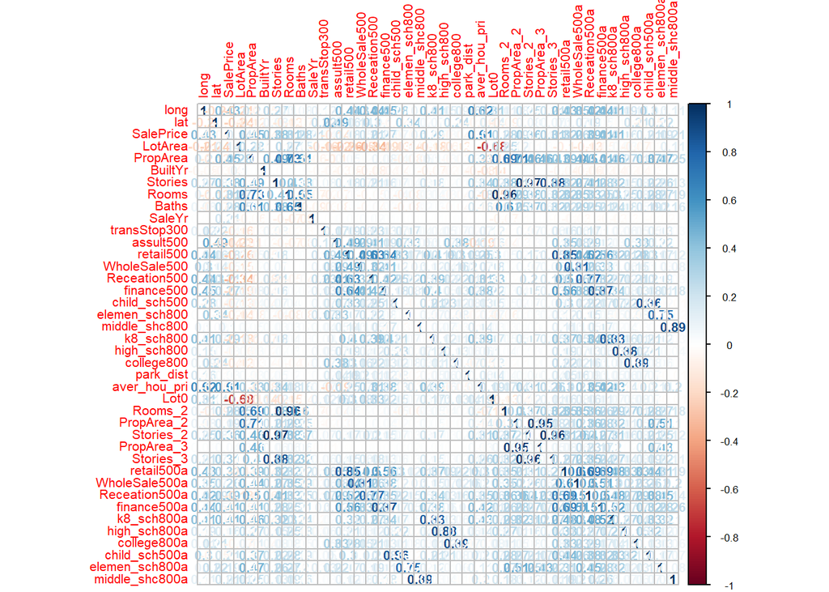

Here we put 4 home price correlation scatterplots that show interesting correlation between house price and average houseprice of nearest 5 neighbors, property areas, the assults happened within 500 meters of the houses, and the built year of the houses.

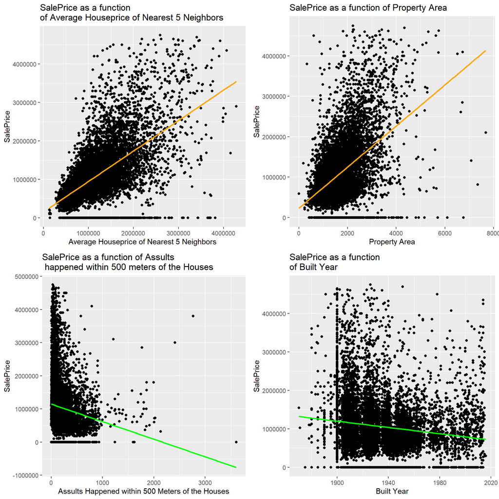

Below is the map of sale prices.

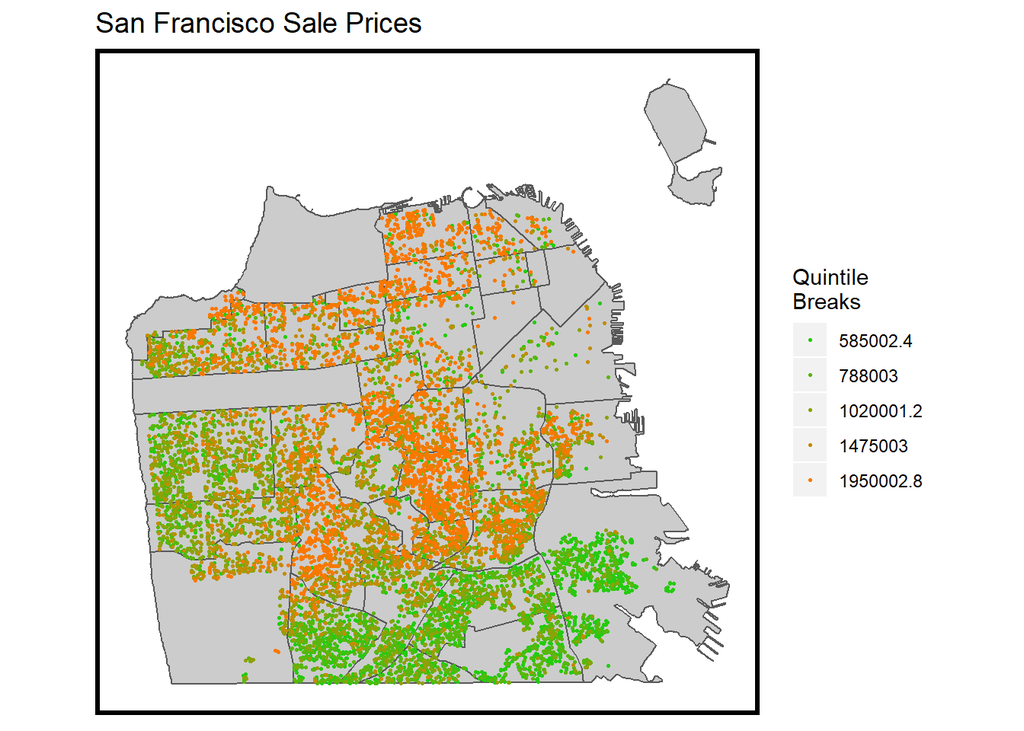

Below are 3 maps of assaults happened nearby, nearby average houseprices, and the property areas. We can conclude from the graph that there are obvious spatial lag in the crimes and the neighbourhood houseprices, while the property of the houses tend to disperse. Compare the Graph A with the Graph B, we can conclude that there seem to have inverse spatial distribution of the crime and the neighborhood houseprice: the area with high neighbourhood price tend to have low assault crimes, vice verse.

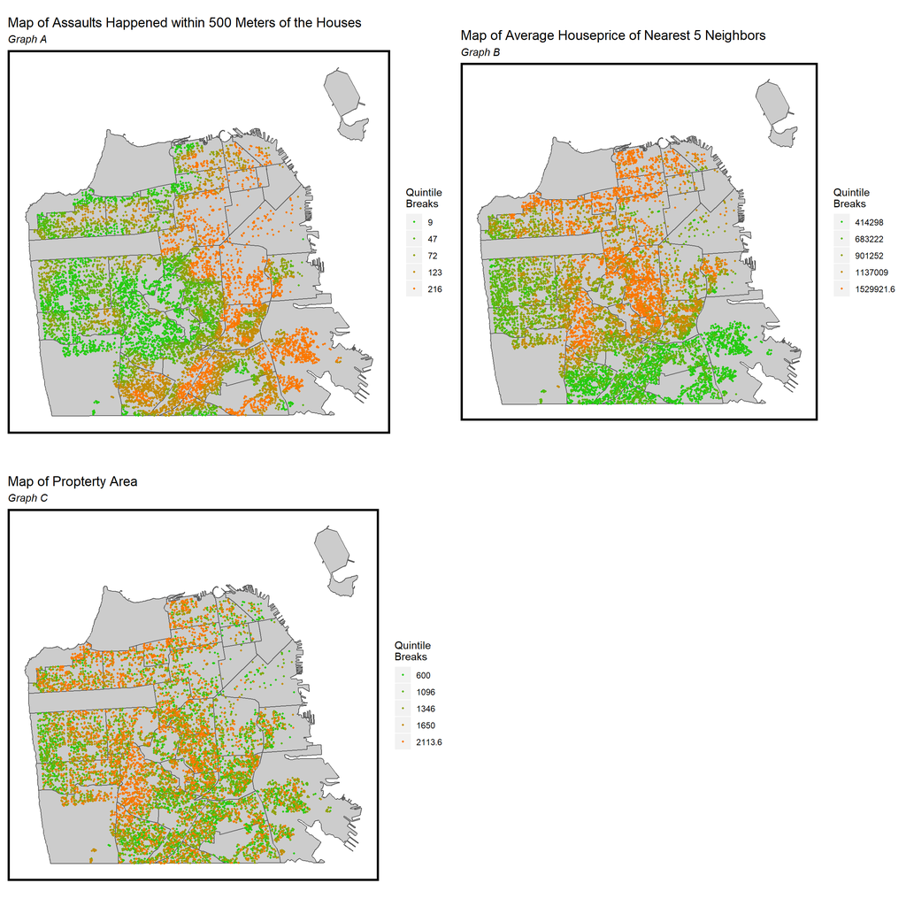

# 3. Methods

The modeling process could be divided into three main parts:

##### 1).Data Wrangling

After gathering the three aspects of data online, we cleaned them carefully. We dealt with NAs by sub-regressions. (For instances, the number of rooms has a strong correlation with the number of beds and baths. We used beds and baths to predict the missing values of rooms, and discarded beds in the final regression model.)

##### 2).Feature Engineering

First, to process the raw amenity data, we made different scales of buffers, and calculated the number of amenities in these buffers. Second, we adjusted the forms to present different characteristics. For example, we changed the built year of houses into dummy variables and this led to a better performance of regression. Besides, we added some quadratic and cubic terms of some important variables, such as property area. Third, to avoid collinearity, we tested the impact of different variables and selected those with the strongest predictive effects, such as the number of assaults in 500-meter buffers of all the crime data.

##### 3).Model Building

The model building process was simultaneous with feature engineering. We used OLS regression model to predict the house prices in San Francisco. To test the accuracy and generalizability, we first split the data into training and testing sets (4:1), then did cross validation to avoid overfitting.

# 4. Results

The table below is the result of the training data. These coefficients represent the relation between sale prices and other factors

|  | Coefficient |
| --- | --- |
| (Intercept) | -142699903.5089372 |
| PropClassD | 1048731.9107191 |
| PropClassDA | 966236.4291975 |
| PropClassF | 902671.8864445 |
| PropClassLZ | 558522.4181356 |
| PropClassOZ | 105752.5382153 |
| PropClassTH | 747999.6749170 |
| PropClassTIC | -254478.4485791 |
| PropClassZ | 623632.2679875 |
| PropClassZBM | 264326.8348053 |
| PropClassZEU | 2654049.0137797 |
| long | 9099731.7996825 |
| lat | 1636122.7386024 |
| ConstTypeB | -314835.1497072 |
| ConstTypeC | 510961.4178534 |
| ConstTypeD | 352880.7452385 |
| ConstTypeF | 254743.1958032 |
| ConstTypeN | 399009.1448538 |
| ConstTypeS | -232421.7310069 |
| ConstTypeSTE | 169161.2166637 |
| ConstTypeWOO | 323034.0328338 |
| LotArea | 0.5658663 |
| PropArea | 299.7713882 |
| BuiltYr | -2255.4269457 |
| Stories | -361991.3382503 |
| Rooms | 67425.0204117 |
| Baths | -1655.4706558 |
| SaleYr | 168210.6417621 |
| transStop300 | -4719.7884113 |
| assult500 | -73.6916095 |
| retail500 | -1684.1195770 |
| WholeSale500 | 4525.0052247 |
| Receation500 | -1050.9231913 |
| finance500 | -21998.5703929 |
| child_sch500 | -8081.7989777 |
| elemen_sch800 | 44629.5391751 |
| middle_shc800 | -54233.4650071 |
| k8_sch800 | 4903.4436239 |
| high_sch800 | -62244.4598023 |
| college800 | 111406.6640397 |
| park_dist | -76.0541290 |
| aver_hou_pri | 0.1962231 |
| BtypeB1890 | 622069.3444193 |
| BtypeB1900 | 567497.5928865 |
| BtypeB1913 | 542627.1730191 |
| BtypeB1920 | 604752.3575218 |
| BtypeB1927 | 590033.1682924 |
| BtypeB1934 | 626233.9661762 |
| BtypeB1942 | 648783.9998590 |
| BtypeB1945 | 729885.2168676 |
| BtypeB1960 | 676381.0331886 |
| BtypeB1970 | 690942.2347434 |
| BtypeB1980 | 680264.0860912 |
| BtypeB1990 | 713800.3759693 |
| BtypeB2000 | 825648.8125985 |
| BtypeB2010 | 818869.6873622 |
| BtypeB2011 | 1206015.7265874 |
| BtypeB2012 | 1031468.0343992 |
| BtypeB2013 | 1009539.5339698 |
| BtypeB2014 | 933772.8719947 |
| BtypeB2015 | 992596.0274805 |
| BtypeB2016 | 144232.0464024 |
| BtypeN | -3651787.0678911 |
| Lot0 | 105769.2330608 |
| Rooms_2 | -4829.0031755 |
| PropArea_2 | 0.0039741 |
| Stories_2 | 183802.5085685 |
| PropArea_3 | -0.0000008 |
| Stories_3 | -22902.1473752 |
| retail500a | 0.2097743 |
| WholeSale500a | -4.0107859 |
| Receation500a | 2.5227211 |
| finance500a | 13.4708100 |
| k8_sch800a | 1.6280298 |
| high_sch800a | 19.0987800 |
| college800a | -84.4448806 |
| child_sch500a | 4.4236308 |
| elemen_sch800a | -29.4748509 |
| middle_shc800a | 28.5466614 |

Below is a polished table of R^2, mean absolute error and MAPE for the test set.

Statistical Measure on test set

| R Square | MAE | MAPE |
| --- | --- | --- |
| 0.7571 | 208717.2 | 20.67 % |

Below is the result of cross validation. It is to test whether the model is overfit.

Statistical Measure on Cross Validation

| Mean of Cross Validation | Standard Error of Cross Validation |
| --- | --- |
| 229749.4 | 29309.85 |

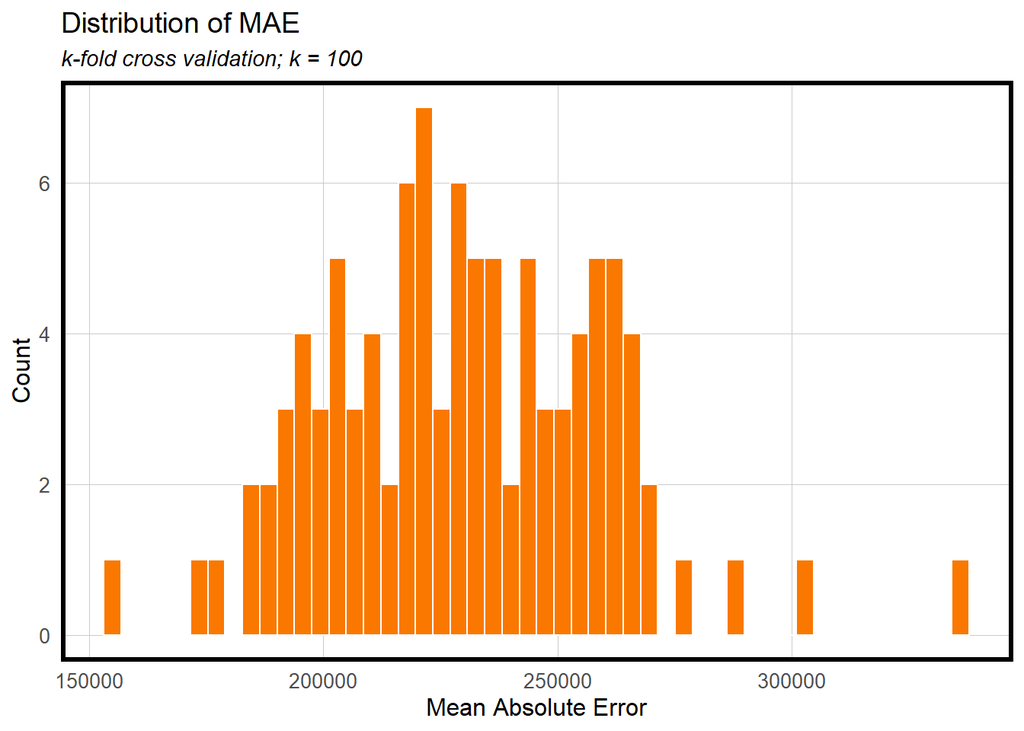

The model is not overfit. Because the mean MAE in cross validation process is similar to the MAE of regression model.

To detect the accuracy, we plot predicted prices as a function of observed prices

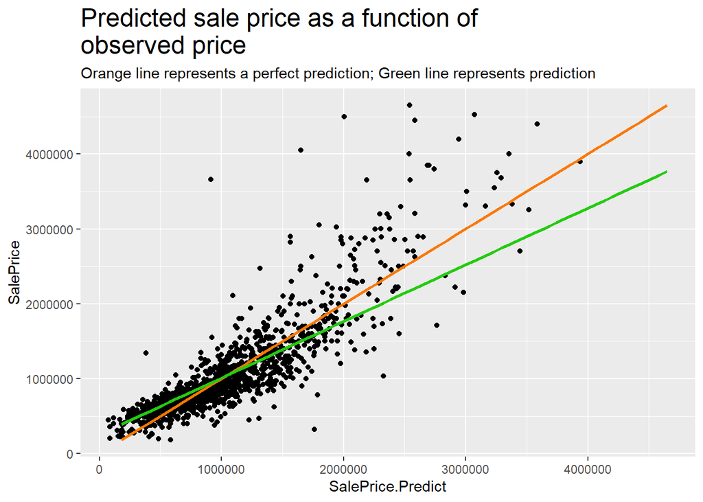

To test whether the errors are clustered spatially, we make a residual map and calculate Moran’s I

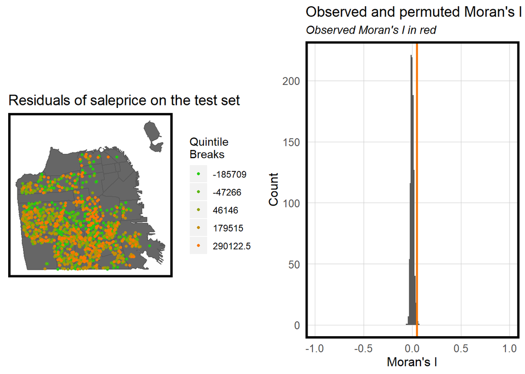

The residual map and Moran’s I shows that the errors are slightly clustered. However, generally the errors are random.

Below is the MAPE by neighborhoods.

[figure not shown]

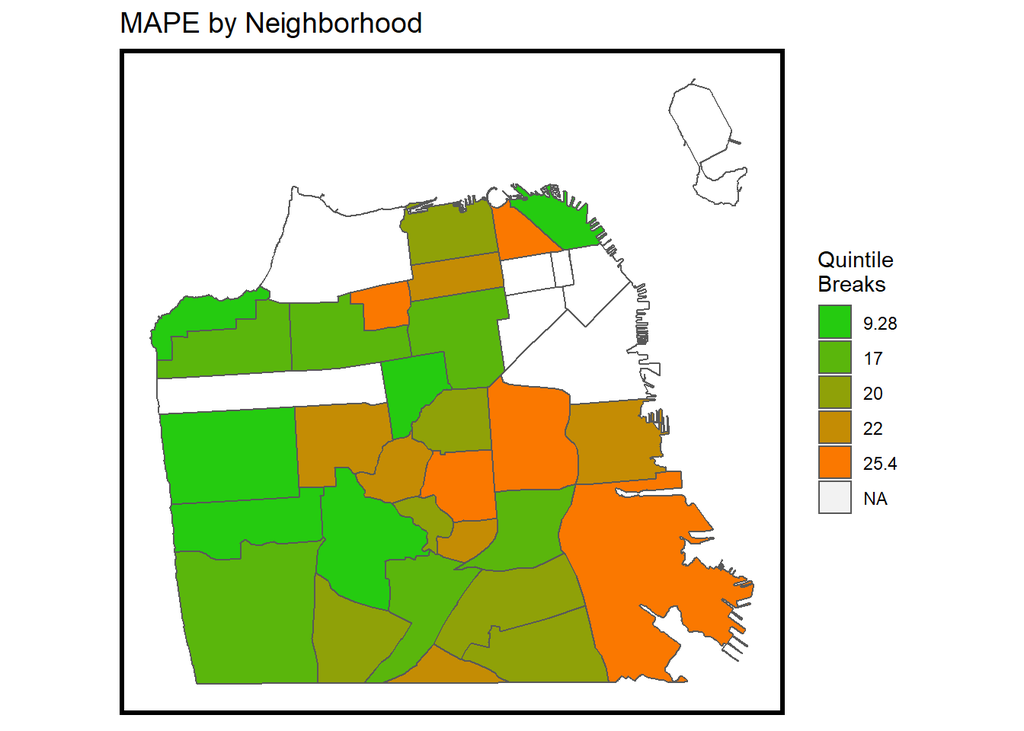

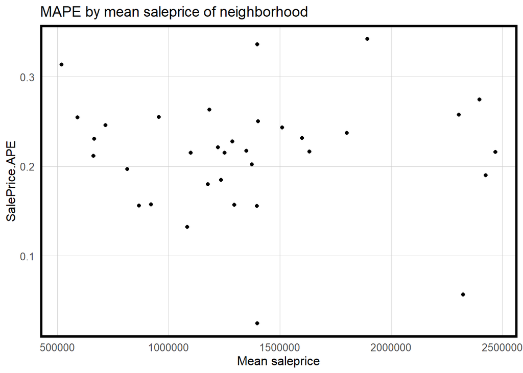

The MAPE by neighborhood doesn’t have an obvious correlation of the mean sale price of the neighborhood.

To test the generalizability of the model among different groups, we split the city into two categories by race, one with majority of white residents and one not. Then we calculate the MAPE of the two groups of neighborhoods respectively.

MAPE by Race

| majority_white | SalePrice.APE |
| --- | --- |
| FALSE | 0.2030690 |
| TRUE | 0.2357205 |

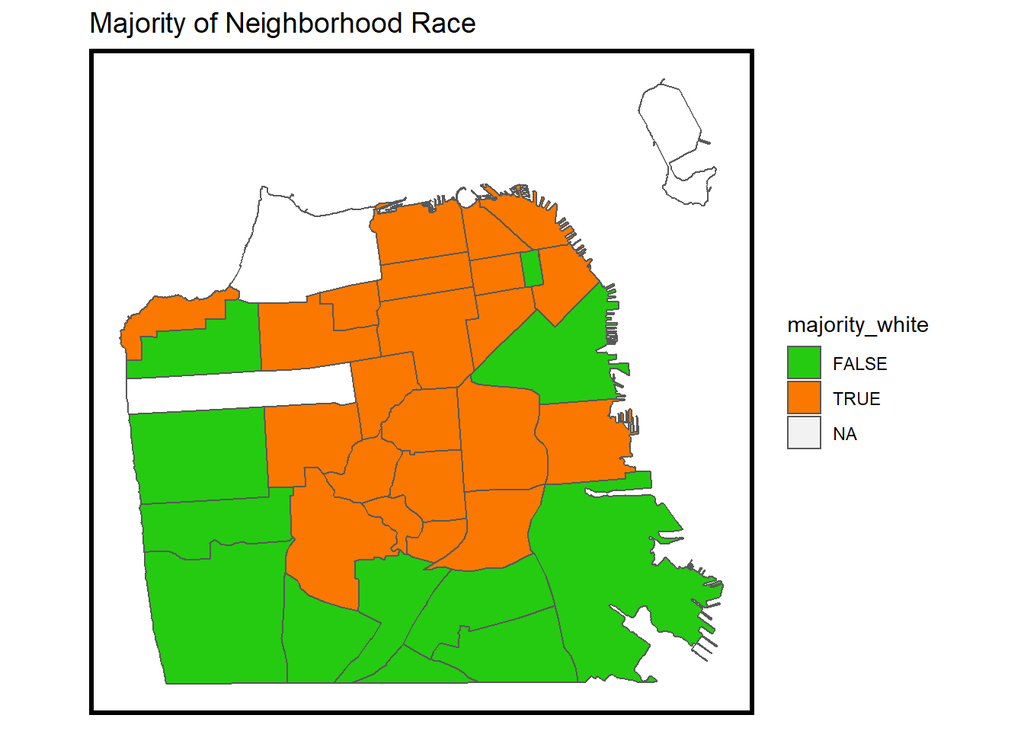

# 5. Discussion

##### 1).Effectiveness

Generally, we believe that our model is effective, for it can predict at least 75% of the variation of house price.

##### 2).Interesting and Important Variables

There are several interesting variables. For example, we used the park-score data. The distance between a house and its nearest high-quality park (score over 90) has a negative impact on house price. The most important variables are still internal ones, and property area is the most essential of all. The relation between these internal characteristics and sale price are not often linear, so we add some quadratic and cubic terms. Besides, the average price of 5-nearest houses is also a good predictor of the house sale price.

##### 3).Spatial differences and error analysis

The error of prediction is around $200,000 on average, about 20% of the sale prices. According to the data and model, house prices are high in the northern and middle parts of the city, and low in southern and western parts. This model does well in predict low house prices, and not satisfying in predicting luxury houses. We believe that it is possibly because the high quality of a house might be affected by more specific features such as design and historical value.

# 6. Conclusion

I would recommend our model to Zillow, for we have taken a lot of characteristics into account and the performance is relatively good. However, there are still several ways to promote the model. First, as the model performs poorly when predicting high-price houses, we could improve the model by conducting more eature engineering and find the variables that contribute to high house price most. Second, this model lacks sufficient theory support. For instance, the amenity conditions are based on buffers. However, we determine the scales of the buffers by our own domain experience and some minor adjustments in feature engineering. It would be better if there is a theory behind to support the choices of the range of influence. Third, the relation between house prices and other factors are not necessarily linear. Although we have already added some exponentiation of independent variables, it is arbitrary and the model maybe still not characterise the relationship very well. A more advanced algorithm will probably contribute to a better prediction.